# SVM, Random Forests, and beyond

Pablo Barbera

August 8, 2017

### Support Vector Machines

Continuing with our previous example, we’ll now try other classifiers. First up is SVMs – the code below illustrates a common trade-off between performance and interpretability of the model.

```r
library(quanteda)
tweets <- read.csv("../data/UK-tweets.csv", stringsAsFactors=F)
tweets$engaging <- ifelse(tweets$communication=="engaging", 1, 0)
tweets <- tweets[!is.na(tweets$engaging),]
# clean text and create DFM
tweets$text <- gsub('@[0-9_A-Za-z]+', '@', tweets$text)
twcorpus <- corpus(tweets$text)
twdfm <- dfm(twcorpus, remove=stopwords("english"), remove_url=TRUE,
             ngrams=1:2, verbose=TRUE)
```

```
## Creating a dfm from a corpus ...
```

```
##    ... tokenizing texts
```

```
##    ... lowercasing
```

```
##    ... found 4,566 documents, 48,721 features
```

```
## ...
```

```
## dfm_select removed 19,434 features and 0 documents, padding 0s for 0 features and 0 documents.
```

```
##    ... created a 4,566 x 29,287 sparse dfm
##    ... complete.
## Elapsed time: 38.3 seconds.
```

```r
twdfm <- dfm_trim(twdfm, min_docfreq = 2, verbose=TRUE)
```

```
## Removing features occurring:
```

```
##   - in fewer than 2 document: 22,883
```

```
##   Total features removed: 22,883 (78.1%).
```

```r
# training and test sets
set.seed(123)
training <- sample(1:nrow(tweets), floor(.80 * nrow(tweets)))
test <- (1:nrow(tweets))[1:nrow(tweets) %in% training == FALSE]
```

First, let’s run SVM by choosing manually the cost parameter (regularization term).

```r
library(e1071)
fit <- svm(x=twdfm[training,], y=factor(tweets$engaging[training]),
           kernel="linear", cost=10, probability=TRUE)

preds <- predict(fit, twdfm[test,])

## function to compute accuracy
accuracy <- function(ypred, y){
    tab <- table(ypred, y)
    return(sum(diag(tab))/sum(tab))
}
# function to compute precision
precision <- function(ypred, y){
    tab <- table(ypred, y)
    return((tab[2,2])/(tab[2,1]+tab[2,2]))
}
# function to compute recall
recall <- function(ypred, y){
    tab <- table(ypred, y)
    return(tab[2,2]/(tab[1,2]+tab[2,2]))
}

# confusion matrix
table(preds, tweets$engaging[test])
```

```
##
## preds   0   1
##     0 126  76
##     1  67 645
```

```r
# performance metrics
accuracy(preds, tweets$engaging[test])
```

```
## [1] 0.8435449
```

```r
precision(preds, tweets$engaging[test])
```

```
## [1] 0.9058989
```

```r
recall(preds, tweets$engaging[test])
```

```
## [1] 0.8945908
```

Unlike regularized regression, here looking at the estimated coefficients is not as informative because they only tell us what support vectors were estimated in the model. But we can have a sense of what observations are more “important” or “separate” better the data by extracting the support vectors in the data matrix and then their corresponding coefficients (times the training labels):

```r
df <- data.frame(
  vector = tweets$text[training][fit$index],
  coef = fit$coefs,
  stringsAsFactors = F
)

df <- df[order(df$coef),]
head(df[,c("coef", "vector")], n=10)
```

```
##            coef
## 1292 -10.000000
## 1119  -9.949824
## 1192  -9.831176
## 863   -8.374781
## 1302  -7.160137
## 995   -6.568624
## 847   -6.290177
## 1013  -4.945334
## 1270  -4.942520
## 1031  -4.581706
##                                                                                             vector
## 1292                                                                    #wegotthis #partickthistle
## 1119                 MT '@: I've supported Vote #TUSC on May 22nd on @ // @ http://t.co/LnvjxTm4o4
## 1192                     GREEN NEWS Peterborough UK is out! http://t.co/tLn6M2uTi8 Stories via @ @
## 863                                                        #EP2014 cands SWEngland @ @ @ @ @ @ @ @
## 1302                                                                                    @ oh shush
## 995                                               http://t.co/IrhS1H6kzY @ outclassing Ed Milliand
## 847                                                                        @  Yorkshires best hope
## 1013 @ @ @ @ no probs you got your #UnitedHealth man to accompany warner :) http://t.co/45Z5grEwtW
## 1270                                                           In today's @ http://t.co/UAK7jHXkVu
## 1031                                                      So now it begins  http://t.co/dDglFqahHa
```

```r
df <- df[order(df$coef, decreasing=TRUE),]
head(df[,c("coef", "vector")], n=10)
```

```
##          coef
## 233 10.000000
## 499 10.000000
## 594 10.000000
## 610 10.000000
## 702 10.000000
## 764 10.000000
## 822 10.000000
## 583  5.754075
## 629  3.585184
## 179  2.752451
##                                                                            vector
## 233                                                    @ #opportunists #transient
## 499                                              Why Pray? http://t.co/F2C5ZZCJ6v
## 594                                                                       @ #sobs
## 610                                                                @ #ohyesyouare
## 702 MT '@: I've supported Vote #TUSC on May 22nd on @ // @ http://t.co/LnvjxTm4o4
## 764     GREEN NEWS Peterborough UK is out! http://t.co/tLn6M2uTi8 Stories via @ @
## 822                                                                        @ Awks
## 583                                                                   @ @ oh dear
## 629                                                                   @ @ #LEGEND
## 179                                                                  @ no worries
```

Note that this will only work with linear kernels.

There’s a version of svm with cross-validation already built-in. We’ll now use to find the best cost parameter:

```r
fit <- tune(svm, train.x=twdfm[training,],
            train.y=factor(tweets$engaging[training]),
            kernel="linear",
            ranges=list(cost=c(0.001, 0.01, 0.1, 1, 5, 10, 100)))
summary(fit)
```

```
##
## Parameter tuning of 'svm':
##
## - sampling method: 10-fold cross validation
##
## - best parameters:
##  cost
##   0.1
##
## - best performance: 0.113632
##
## - Detailed performance results:
##    cost     error dispersion
## 1 1e-03 0.2231679 0.01707819
## 2 1e-02 0.1897635 0.01126525
## 3 1e-01 0.1136320 0.01541838
## 4 1e+00 0.1355393 0.01418854
## 5 5e+00 0.1453964 0.02193969
## 6 1e+01 0.1500517 0.01992198
## 7 1e+02 0.1437420 0.02342054
```

```r
# best model
bestmodel <- fit$best.model
summary(bestmodel)
```

```
##
## Call:
## best.tune(method = svm, train.x = twdfm[training, ], train.y = factor(tweets$engaging[training]),
##     ranges = list(cost = c(0.001, 0.01, 0.1, 1, 5, 10, 100)),
##     kernel = "linear")
##
##
## Parameters:
##    SVM-Type:  C-classification
##  SVM-Kernel:  linear
##        cost:  0.1
##       gamma:  0.0001561524
##
## Number of Support Vectors:  1630
##
##  ( 964 666 )
##
##
## Number of Classes:  2
##
## Levels:
##  0 1
```

```r
# evaluating performance
preds <- predict(bestmodel, twdfm[test,])
# confusion matrix
table(preds, tweets$engaging[test])
```

```
##
## preds   0   1
##     0 120  39
##     1  73 682
```

```r
# performance metrics
accuracy(preds, tweets$engaging[test])
```

```
## [1] 0.8774617
```

```r
precision(preds, tweets$engaging[test])
```

```
## [1] 0.9033113
```

```r
recall(preds, tweets$engaging[test])
```

```
## [1] 0.9459085
```

```r
df <- data.frame(
  vector = tweets$text[training][bestmodel$index],
  coef = bestmodel$coefs,
  stringsAsFactors = F
)

df <- df[order(df$coef),]
head(df[,c("coef", "vector")], n=10)
```

```
##     coef
## 965 -0.1
## 966 -0.1
## 968 -0.1
## 970 -0.1
## 971 -0.1
## 972 -0.1
## 973 -0.1
## 974 -0.1
## 975 -0.1
## 976 -0.1
##                                                                                                                                vector
## 965                                                          .@ Sally Ibbotson @ comes in second after Labour. http://t.co/MM0KdqPl7A
## 966                              @ is Britain's Berlusconi – someone foreigners look at and say, "How can you vote for this buffoon?"
## 968                                                                    Unusual polling stations - in pictures  http://t.co/sGmewcCHZd
## 970 While UKIP miss or oppose key votes, @ are working hard to stand up for UK citizens http://t.co/jxwJAF71a5 http://t.co/RHkFhUsG7n
## 971                                            @ spotted among good friends at @ event in Manchester #EU2014 @ http://t.co/AAI63wqLzE
## 972                                                                                         Congratulations to @ on being re-elected!
## 973                                              Hesketh Park looking fantastic in the sunshine #lovesouthport http://t.co/ygfI15LgVZ
## 974                                                                        Forest carbon loss 'underestimated' http://t.co/fXjglnu849
## 975                                                                  "seedbombing" one of the more innovative suggestions at #leithnp
## 976                                                                           @ @ Well done to everyone in #Winchester, great result!
```

```r
df <- df[order(df$coef, decreasing=TRUE),]
head(df[,c("coef", "vector")], n=10)
```

```
##    coef
## 1   0.1
## 5   0.1
## 8   0.1
## 22  0.1
## 25  0.1
## 28  0.1
## 33  0.1
## 37  0.1
## 41  0.1
## 42  0.1
##                                                                                                                        vector
## 1                      @ to be fair I think people have been listening to your leader rather than labour this last day or two
## 5  Thanks to @ &amp; @ for covering our https://t.co/GcPbvFVvnY report on BBC ‘Click’. Listen again at http://t.co/iB4Wx9ZuyQ
## 8                                                                          @ @ Is this truly the best use of his time? WTF...
## 22                                                      Congratulations to @  and @  elected Yorkshire &amp;Humber MEP Labour
## 25                                                       Greens to launch LGBTIQ European manifesto @  http://t.co/XzqauVWLIk
## 28                           LOOK @ LOOK. THERE IN THAT BUSH. A ROMANIAN GANG. HELP ME NIGEL. HELP ME! http://t.co/BWXzPN3WBr
## 33                                             Out + about with #Peterborough's MEP @ #cllrdarrenfower http://t.co/VN7g94AcJw
## 37                                                                                                     @ Bully for you Jimbo.
## 41                                                              @ over to you whether you believe me or now - have a good day
## 42                                     @ @ Labour won't stop them, most of their "new core vote" is "gladly" employed on them
```

### Random forests

Turning to random forests, we’ll need to dramatically reduce the size of our matrix to make sure it doesn’t take hours to run; so we’ll just pick features that are not frequent but also not too rare. We’ll see that random forests tend to perform quite well, but at the cost of higher computational cost and even less interpretability (we can only learn of “feature importance” – the extent to which a variable tends to separate classes more frequently than others).

```r
library(randomForest)
set.seed(777)

X <- as.matrix(dfm_trim(twdfm, min_docfreq = 100,
                        max_docfreq=0.50, verbose=TRUE))
```

```
## Removing features occurring:
```

```
##   - in fewer than 100 document: 6,355
```

```
##   - in more than 0.5 * 4,566 = 2283 documents: 1
```

```
##   Total features removed: 6,356 (99.3%).
```

```r
dim(X)
```

```
## [1] 4566   48
```

```r
rf <- randomForest(x=X[training,],
                   y=factor(tweets$engaging[training]),
                   xtest=X[test,],
                   ytest=factor(tweets$engaging[test]),
                   importance=TRUE,
                   mtry=20,
                   ntree=100
                   )
rf
```

```
##
## Call:
##  randomForest(x = X[training, ], y = factor(tweets$engaging[training]),      xtest = X[test, ], ytest = factor(tweets$engaging[test]),      ntree = 100, mtry = 20, importance = TRUE)
##                Type of random forest: classification
##                      Number of trees: 100
## No. of variables tried at each split: 20
##
##         OOB estimate of  error rate: 21.08%
## Confusion matrix:
##     0    1 class.error
## 0 287  528  0.64785276
## 1 242 2595  0.08530137
##                 Test set error rate: 22.54%
## Confusion matrix:
##    0   1 class.error
## 0 64 129   0.6683938
## 1 77 644   0.1067961
```

```r
importance(rf)
```

```
##                   0          1 MeanDecreaseAccuracy MeanDecreaseGini
## @_@      37.0591393  5.1330947          24.35295338       148.436027
## .         2.2077588 11.0443068          10.94196167        62.814092
## ,        -0.6445278  6.4151530           4.91961821        50.155351
## !         3.2703377  9.7092049          10.24566714        30.521642
## -         1.0807046  6.1676062           5.33884794        41.109172
## ?         5.4530106  9.4431504          12.10631785        23.140647
## ._.       4.9693193  1.4545987           5.79044988        12.521191
## :         6.7557834 22.6970549          22.66563041        30.149120
## "        -0.1610388  9.4037342           7.31626553        23.166396
## ;        -1.2919329  3.3067743           2.45153122        10.048398
## &         0.4340685  1.4042727           1.52820132         7.165417
## thanks    4.3403241  8.6832736          10.54096758        16.346200
## '        17.4606602  7.5486075          15.35116395        18.711078
## amp       1.5540507  0.8219733           1.65939974         5.798546
## &_amp     1.4089396  0.3512831           1.24600596         4.988059
## amp_;     1.2226732  1.0170373           1.65911753         5.482137
## ukip     -0.7942597 -2.6917205          -2.73532146        16.960395
## )         3.6388997 12.3705594          13.48982731        24.645757
## will      2.9352934  0.6692725           2.22368557        18.038091
## eu        9.8828157  6.3711686          11.23511966        16.023110
## @_i      21.0016247  5.8606171          15.58696514        19.168988
## good      2.8515823  3.2159069           3.90552519        13.007627
## vote      2.3410761  5.9540549           6.42600713        17.184947
## @_thanks  7.4505275  7.3570028          10.17103596         8.374519
## just     -2.3681141 -2.1662149          -2.84380969        10.988593
## @_:      -3.7806060  8.7215035           6.50077186        10.789094
## people    2.7911736  1.8447207           3.18043192        11.903850
## ._@       0.2849158  2.7865787           2.72141096        10.820952
## can       0.4310705  5.8813046           4.94747106        13.488997
## /        -2.1669557  1.6167847           0.01807378        12.785841
## get       2.7151249 -0.8130386           0.87161831        11.632031
## #ukip     0.3079062  0.6565913           0.67734621        11.291980
## like     -0.4708976 -0.1626357          -0.40108810         8.884090
## well      1.2976795 -3.7911256          -2.61330937         9.382593
## many      0.9205757  5.2266075           5.01284425         8.652394
## one      -2.2907884 -4.8190743          -4.75897215         8.214741
## party    -1.3193110 -0.2250363          -0.92469815         9.694129
## now       0.2392768  1.4494286           1.32712074        11.198776
## great    11.0606701  4.9904038          10.04351164        12.905743
## think    -2.9341642 -1.4123489          -3.15480135         6.194391
## see       1.1279379 -2.2595203          -1.55504420         9.388188
## thank     9.2677774  0.9473403           5.75182807        11.991521
## time     -2.2577953 -2.2311131          -3.00599138         8.349684
## uk        5.4512844  5.6108843           7.59135343        13.876647
## (         6.0555342  2.3219428           5.85169130        15.463936
## @_and     2.1077701  1.9141979           2.77888690        12.023784
## election  1.1732312  5.6106921           5.00068537        13.347527
## labour   -0.5044111 -1.7674750          -1.92174020         9.728319
```

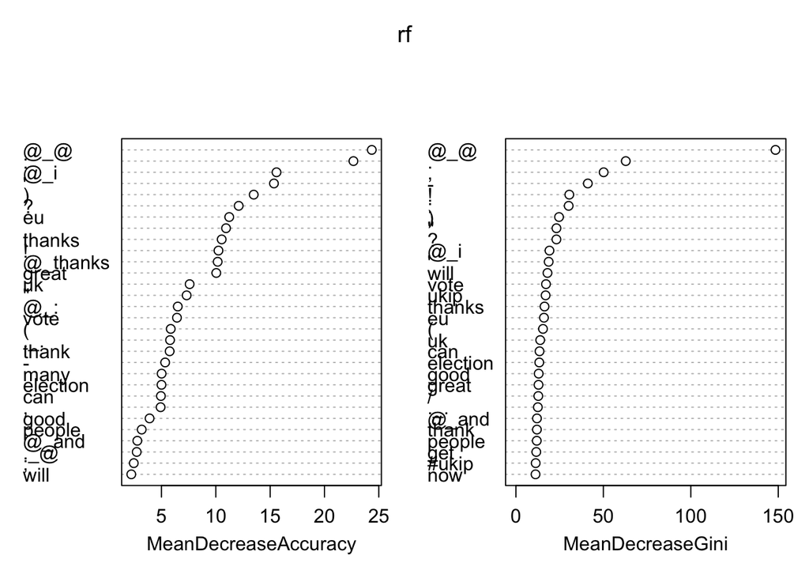

```r
varImpPlot(rf)
```

## Ensemble methods

One interesting way to run supervised learning algorithms is to **combine** the using ensemble methods. The idea is the following: run each method, check how well they perform, and then pick a prediction for the units in the test set that is weighted according to how well each classifier performs. The `SuperLearner` package in R is probably the best library for ensemble methods in ML.

```r
library(SuperLearner)
# X needs to be a data frame
Xtrain <- as.data.frame(dfm_trim(twdfm, min_docfreq = 100,
                        max_docfreq=0.50, verbose=TRUE))
```

```
## Removing features occurring:
```

```
##   - in fewer than 100 document: 6,355
```

```
##   - in more than 0.5 * 4,566 = 2283 documents: 1
```

```
##   Total features removed: 6,356 (99.3%).
```

```r
features <- names(Xtrain)
names(Xtrain) <- paste0("V", 1:ncol(Xtrain))

set.seed(777)

sl <- SuperLearner(Y = tweets$engaging[training], X = Xtrain[training,],
                  family = binomial(),
                  SL.library = c("SL.mean", "SL.glmnet",
                                 "SL.glm", "SL.step.forward"),
                  cvControl=list(V=2))
sl
```

```
##
## Call:
## SuperLearner(Y = tweets$engaging[training], X = Xtrain[training, ],
##     family = binomial(), SL.library = c("SL.mean", "SL.glmnet", "SL.glm",
##         "SL.step.forward"), cvControl = list(V = 2))
##
##
##                          Risk      Coef
## SL.mean_All         0.1736705 0.0000000
## SL.glmnet_All       0.1415206 0.5612423
## SL.glm_All          0.1423589 0.1107414
## SL.step.forward_All 0.1418112 0.3280163
```

```r
# what other classifiers are available?
listWrappers()
```

```
## All prediction algorithm wrappers in SuperLearner:
```

```
##  [1] "SL.bartMachine"      "SL.bayesglm"         "SL.biglasso"
##  [4] "SL.caret"            "SL.caret.rpart"      "SL.cforest"
##  [7] "SL.dbarts"           "SL.earth"            "SL.extraTrees"
## [10] "SL.gam"              "SL.gbm"              "SL.glm"
## [13] "SL.glm.interaction"  "SL.glmnet"           "SL.ipredbagg"
## [16] "SL.kernelKnn"        "SL.knn"              "SL.ksvm"
## [19] "SL.lda"              "SL.leekasso"         "SL.lm"
## [22] "SL.loess"            "SL.logreg"           "SL.mean"
## [25] "SL.nnet"             "SL.nnls"             "SL.polymars"
## [28] "SL.qda"              "SL.randomForest"     "SL.ranger"
## [31] "SL.ridge"            "SL.rpart"            "SL.rpartPrune"
## [34] "SL.speedglm"         "SL.speedlm"          "SL.step"
## [37] "SL.step.forward"     "SL.step.interaction" "SL.stepAIC"
## [40] "SL.svm"              "SL.template"         "SL.xgboost"
```

```
##
## All screening algorithm wrappers in SuperLearner:
```

```
## [1] "All"
## [1] "screen.corP"           "screen.corRank"        "screen.glmnet"
## [4] "screen.randomForest"   "screen.SIS"            "screen.template"
## [7] "screen.ttest"          "write.screen.template"
```

```r
# measuring peformance
preds <- predict(sl, Xtrain[test,])
head(preds$library.predict)
```

```
##      SL.mean_All SL.glmnet_All SL.glm_All SL.step.forward_All
## [1,]   0.7768346     0.9885894  0.9938978           0.9924462
## [2,]   0.7768346     0.5983369  0.5562246           0.5917110
## [3,]   0.7768346     0.9156075  0.9221067           0.9246748
## [4,]   0.7768346     0.6341448  0.6297242           0.6268776
## [5,]   0.7768346     0.6111630  0.5650618           0.6593462
## [6,]   0.7768346     0.8864904  0.8880678           0.8879950
```

```r
preds <- preds$pred > 0.50

# confusion matrix
table(preds, tweets$engaging[test])
```

```
##
## preds     0   1
##   FALSE  47  29
##   TRUE  146 692
```

```r
# performance metrics
accuracy(preds, tweets$engaging[test])
```

```
## [1] 0.8085339
```

```r
precision(preds, tweets$engaging[test])
```

```
## [1] 0.8257757
```

```r
recall(preds, tweets$engaging[test])
```

```
## [1] 0.9597781
```